# IUU fishing pressure

This notebook builds an illegal, unreported, and unregulated (IUU) fishing pressure for the Gulf of California. The source is the IUU Fishing Risk Index (Poseidon Aquatic Resource Management and the Global Initiative Against Transnational Organized Crime). The public file used here is the 2025 data pack, which contains indicator scores for the 2019, 2021, 2023, and 2025 editions:

https://www.iuufishingindex.org/downloads/iuu_fishing_index_2025-data_and_disclaimer.zip

The Index scores 152 coastal countries from 1 to 5. A 1 is the strongest result and a 5 is the weakest. Each indicator belongs to a responsibility (coastal, flag, port, or general) and a type (vulnerability, prevalence, or response). Vulnerability describes exposure, such as the size of an exclusive economic zone. Response describes controls a country has adopted. Prevalence describes illegal fishing that is known or suspected.

## The two indicators in the pressure

The pressure uses Mexico’s **coastal prevalence** score. That is the Index block about illegal fishing in a country’s own waters. It is one national number, so every Gulf region receives the same pressure in a given year. The Index does not separate the Gulf of California from the rest of Mexico’s Pacific, Gulf, and Caribbean coasts.

Coastal prevalence is the weighted mean of two indicators. The study labels each indicator low, medium, or high. In the weighted mean those labels are 1, 2, and 3. The enforcement indicator is high, so it is counted three times. The certification indicator is medium, so it is counted twice. For 2019 the arithmetic is `(2 x 2 + 3 x 3) / 5 = 2.6`.

**Indicator 14, “Has MSC-certified fisheries” (medium weight).** This is a count of Mexican fisheries certified by the Marine Stewardship Council. The 2025 edition uses the MSC list as of May 2025. The study treats certification as evidence that a fishery has been assessed for management and for monitoring and enforcement, including a requirement that the certified fishery be free of illegal catch of the target species. The score bands are 1 for 6 or more certified fisheries, 2 for 3 to 5, 3 for 2, 4 for 1, and 5 for none. Suspended, withdrawn, and still-under-assessment fisheries are left out. A fishery shared by several countries counts once for each of them. The count ignores how much those fisheries catch. Mexico scores 2 in every edition, so it had 3 to 5 certified fisheries each time. The authors also note that this indicator behaves like a measure of management effort, and that it favors countries where MSC has done more outreach.

**Indicator 15, “Views of MCS practitioners on coastal compliance incidents” (high weight).** Monitoring, control, and surveillance practitioners, generally people in government enforcement, answer an anonymous survey. They name the five countries they consider most problematic for illegal activity. A country is scored from how often it is named for compliance incidents inside its own exclusive economic zone, and from where it sits on those lists. Being named first counts more than being named later. The mention rate is then placed in a band: 1 if the country is never named, 2 if the rate is above 0 and below 0.25, 3 for 0.25 up to 0.50, 4 for 0.50 up to 1, and 5 for a rate of 1 or more. The 2023 survey was run in August and September 2023 and refers to 2022 through August 2023. The 2025 survey was run from April to July 2025 and refers to 2024 and 2025. From 2025 the study keeps the previous round of answers along with the new one, because a different set of respondents can change who gets named. Mexico scores 3 in 2019, 1 in 2021, and 2 in 2023 and 2025. A 1 means Mexico was not named. A 2 means it was named only rarely. This survey is the study’s substitute for a count of illegal catch. The answers depend on who responds and where those people work.

## Scores left out

**Flag.** The flag score follows vessels on Mexico’s register, including boats fishing outside Mexican waters. This pressure is for fishing in Mexican waters.

**Port.** The port score is about landings and inspections when fishing boats and carrier boats use Mexican ports, especially foreign vessels. Mexico’s 2025 port vulnerability is 4.50 because it has many ports and foreign vessels visit them. Port prevalence is 1.50, from the same style of survey aimed at incidents in ports. Port response is 1.00, from joining the Port State Measures Agreement, designating ports for foreign entry, and meeting port-state rules of regional fishery bodies.

**General.** The general score is the block the study could not assign to waters, boats, or ports. Vulnerability includes the corruption-perception index, national income, the size of Mexico’s catch relative to the world, and the seafood trade balance. Response includes vessel-tracking rules, ratification of the Law of the Sea and the UN Fish Stocks Agreement, demand for certified seafood, and news mentions of Mexico fighting illegal fishing. The prevalence piece inside this block is still a set of country designations: a European Union card (Mexico scores 1, meaning no card, in every edition), a NOAA identification of the whole country (5 in 2019, 2023, and 2025, and 4 in 2021), and Mexico’s share of an English-language fisheries news roundup. Income, treaty status, and a busy news year would move a pressure built from this score.

**Coastal vulnerability and coastal response.** These sit beside coastal prevalence, and they are recomputed below only to check the weights. Coastal vulnerability describes exposure. Mexico’s 2025 score is 4.25, largely because its exclusive economic zone scores 5 and its unresolved maritime boundaries score 5. Coastal response describes controls Mexico has adopted, including regional-fishery membership and a national vessel-monitoring centre. Mexico’s 2025 score is 2.60. Matching those two published numbers is the check that low = 1, medium = 2, and high = 3.

A blank indicator score is left out of any mean. Mexico has no score for foreign vessels authorised to fish in its exclusive economic zone. That indicator is coastal vulnerability, so it stays out of this pressure.

The pressure rescales the 1–5 coastal prevalence score onto 0–1:

`pressure = round((coastal prevalence - 1) / 4, 2)`.

A prevalence of 1 becomes 0. A prevalence of 5 becomes 1. The score from each edition is held through the year before the next edition. The 2025 edition is the last one in the file, so it is used for 2025 only.

```r
library(tidyverse)
```

```r
library(knitr)

knitr::opts_chunk$set(message = FALSE, warning = FALSE)

iuu_dir <- "/home/frazier/ohi_goc_prep/_pressures/prs_iuu"
raw_dir <- file.path(iuu_dir, "raw")
out_dir <- file.path(iuu_dir, "output")
fig_dir <- file.path(iuu_dir, "figures")
dir.create(out_dir, showWarnings = FALSE, recursive = TRUE)
dir.create(fig_dir, showWarnings = FALSE, recursive = TRUE)

# 2025 data pack. It holds the indicator scores for every edition from 2019.
zip_url <- "https://www.iuufishingindex.org/downloads/iuu_fishing_index_2025-data_and_disclaimer.zip"
zip_path <- file.path(raw_dir, "iuu_fishing_index_2025-data_and_disclaimer.zip")
csv_name <- "iuu_fishing_index_2019-2025_indicator_scores.xlsx - 2019-2025 indicator scores.csv"
csv_path <- file.path(raw_dir, csv_name)

# Marine region ids. Land polygons repeat the same nine ids and are not used.
rgn_path <- "/home/frazier/ohi_goc_prep/spatial/ohi_regions/ohi_rgns_core.csv"

# Low, medium, and high in the Index methodology.
weight_value <- c(low = 1, medium = 2, high = 3)

# Weights for the coastal indicators used below. Prevalence enters the
# pressure. Vulnerability and response are recomputed only as a check
# against the published Mexico profile.
indicator_weight <- tribble(
  ~indicator_id, ~weight_name,
  10, "medium",
  11, "low",
  12, "low",
  13, "medium",
  14, "medium",
  15, "high",
  16, "medium",
  17, "high"
) %>%
  mutate(weight = weight_value[weight_name])
```

## 1. Read the indicator file

The zip is downloaded only when the indicator table is not already in `raw/`. The table has one row per indicator, country, and edition.

```r
if (!file.exists(csv_path)) {
  dir.create(raw_dir, showWarnings = FALSE, recursive = TRUE)
  if (!file.exists(zip_path)) {
    download.file(zip_url, zip_path, mode = "wb", quiet = TRUE)
  }
  unzip(zip_path, files = csv_name, exdir = raw_dir)
}

scores <- read_csv(csv_path, show_col_types = FALSE) %>%
  transmute(
    indicator_id = as.integer(`Indicator ID`),
    indicator_name = `Indicator name`,
    country = Country,
    responsibility = Resp,
    type = Type,
    year = as.integer(Year),
    score = suppressWarnings(as.numeric(Score))
  )

mexico <- scores %>%
  filter(country == "Mexico", responsibility == "Coastal") %>%
  left_join(indicator_weight, by = "indicator_id")

cat("Indicator rows:", nrow(scores), "\n")
```

```
## Indicator rows: 24320
```

```r
cat("Editions:", paste(sort(unique(scores$year)), collapse = ", "), "\n")
```

```
## Editions: 2019, 2021, 2023, 2025
```

```r
cat("Mexico coastal rows:", nrow(mexico), "\n")
```

```
## Mexico coastal rows: 32
```

A group score is the weighted mean of the indicators that have a number. Blank scores stay out of both the numerator and the denominator.

```r
group_score <- function(data, group_type) {
  data %>%
    filter(type == group_type, !is.na(score), !is.na(weight)) %>%
    group_by(year) %>%
    summarise(
      score = sum(score * weight) / sum(weight),
      .groups = "drop"
    ) %>%
    mutate(score = round(score, 2))
}
```

## 2. Check the weights against the Mexico profile

The 2025 profile publishes coastal vulnerability as 4.25 and coastal response as 2.60. Those two groups use the same weights as coastal prevalence. Matching them is the check that low = 1, medium = 2, and high = 3.

```r
vulnerability <- group_score(mexico, "Vulnerability")
response <- group_score(mexico, "Response")

vulnerability_2025 <- vulnerability$score[vulnerability$year == 2025]
response_2025 <- response$score[response$year == 2025]

cat("2025 coastal vulnerability:", vulnerability_2025, "\n")
```

```
## 2025 coastal vulnerability: 4.25
```

```r
cat("2025 coastal response:", response_2025, "\n")
```

```
## 2025 coastal response: 2.6
```

```r
stopifnot(vulnerability_2025 == 4.25)
stopifnot(response_2025 == 2.60)
```

## 3. Coastal prevalence

```r
prevalence_indicators <- mexico %>%
  filter(type == "Prevalence") %>%
  arrange(year, indicator_id) %>%
  select(year, indicator_id, indicator_name, weight_name, score)

kable(
  prevalence_indicators,
  caption = "Mexico coastal prevalence indicators"
)
```

Mexico coastal prevalence indicators

| year | indicator_id | indicator_name | weight_name | score |
| --- | --- | --- | --- | --- |
| 2019 | 14 | Has MSC-certified fisheries | medium | 2 |
| 2019 | 15 | Views of MCS practitioners on coastal compliance incidents | high | 3 |
| 2021 | 14 | Has MSC-certified fisheries | medium | 2 |
| 2021 | 15 | Views of MCS practitioners on coastal compliance incidents | high | 1 |
| 2023 | 14 | Has MSC-certified fisheries | medium | 2 |
| 2023 | 15 | Views of MCS practitioners on coastal compliance incidents | high | 2 |
| 2025 | 14 | Has MSC-certified fisheries | medium | 2 |
| 2025 | 15 | Views of MCS practitioners on coastal compliance incidents | high | 2 |

```r
prevalence <- group_score(mexico, "Prevalence") %>%
  rename(coastal_prevalence = score)

# The 2025 profile publishes this group score as 2.00.
stopifnot(prevalence$coastal_prevalence[prevalence$year == 2025] == 2)

kable(
  prevalence,
  digits = 2,
  caption = "Mexico coastal prevalence by Index edition"
)
```

Mexico coastal prevalence by Index edition

| year | coastal_prevalence |
| --- | --- |
| 2019 | 2.6 |
| 2021 | 1.4 |
| 2023 | 2.0 |
| 2025 | 2.0 |

The 2021 edition is lower because the enforcement-view indicator is 1 in that edition and 2 or 3 in the others. The certification indicator stays at 2 throughout.

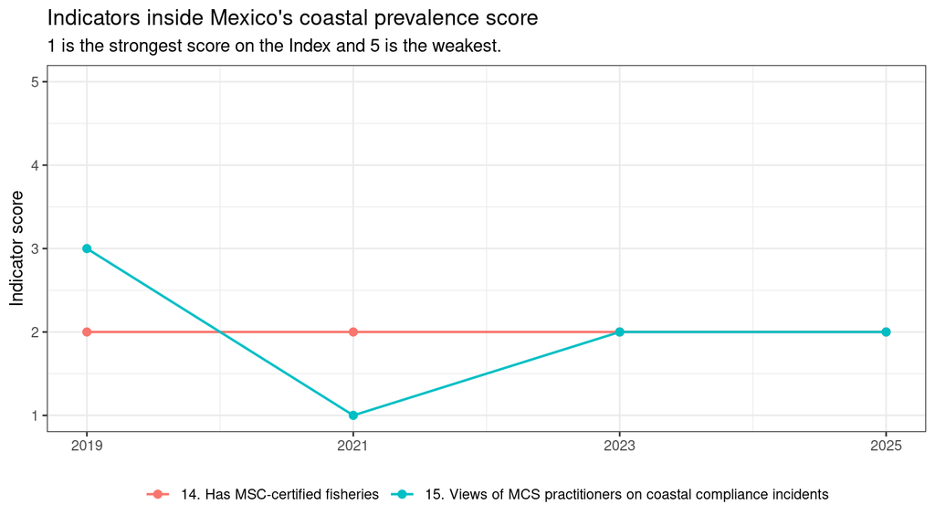

```r
prevalence_indicators %>%
  mutate(indicator = paste0(indicator_id, ". ", indicator_name)) %>%
  ggplot(aes(year, score, color = indicator)) +
  geom_line(linewidth = 0.7) +
  geom_point(size = 2) +
  scale_x_continuous(breaks = sort(unique(prevalence_indicators$year))) +
  scale_y_continuous(limits = c(1, 5), breaks = 1:5) +
  labs(
    title = "Indicators inside Mexico's coastal prevalence score",
    subtitle = "1 is the strongest score on the Index and 5 is the weakest.",
    x = NULL,
    y = "Indicator score",
    color = NULL
  ) +
  theme_bw() +
  theme(legend.position = "bottom")
```

## 4. Pressure

The edition score is held until the next edition. It is then rescaled to the 0–1 pressure used by the other layers and repeated for all nine marine regions.

```r
edition_years <- prevalence %>% arrange(year)

held <- tibble(year = min(edition_years$year):max(edition_years$year)) %>%
  mutate(
    edition = map_int(year, function(y) {
      max(edition_years$year[edition_years$year <= y])
    })
  ) %>%
  left_join(
    edition_years %>% select(edition = year, coastal_prevalence),
    by = "edition"
  ) %>%
  mutate(pressure = round((coastal_prevalence - 1) / 4, 2))

regions <- read_csv(rgn_path, show_col_types = FALSE) %>%
  filter(location == "marine") %>%
  distinct(rgn_id)

pressure <- regions %>%
  crossing(held) %>%
  select(rgn_id, year, pressure) %>%
  arrange(year, rgn_id)

stopifnot(n_distinct(pressure$rgn_id) == 9)
stopifnot(nrow(pressure) == 9 * n_distinct(pressure$year))
stopifnot(all(pressure$pressure >= 0), all(pressure$pressure <= 1))
# One national score: regions do not differ inside a year.
stopifnot(all(tapply(pressure$pressure, pressure$year, n_distinct) == 1))

pressure_path <- file.path(out_dir, "iuu_pressure.csv")
write_csv(pressure, pressure_path)

cat("Wrote", pressure_path, "\n")
```

```
## Wrote /home/frazier/ohi_goc_prep/_pressures/prs_iuu/output/iuu_pressure.csv
```

```r
cat("Rows:", nrow(pressure), "\n")
```

```
## Rows: 63
```

```r
kable(
  held,
  digits = 2,
  caption = "National score held between Index editions, and the pressure"
)
```

National score held between Index editions, and the pressure

| year | edition | coastal_prevalence | pressure |
| --- | --- | --- | --- |
| 2019 | 2019 | 2.6 | 0.40 |
| 2020 | 2019 | 2.6 | 0.40 |
| 2021 | 2021 | 1.4 | 0.10 |
| 2022 | 2021 | 1.4 | 0.10 |
| 2023 | 2023 | 2.0 | 0.25 |
| 2024 | 2023 | 2.0 | 0.25 |
| 2025 | 2025 | 2.0 | 0.25 |

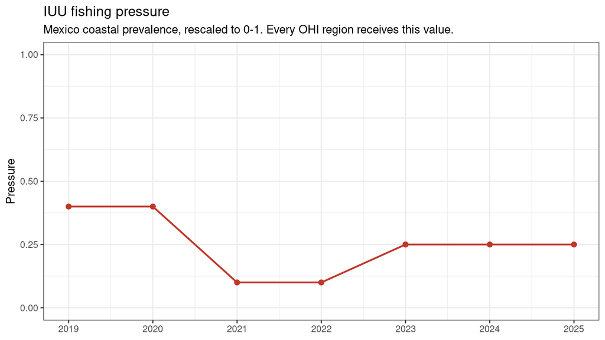

```r
pressure_plot <- held %>%
  ggplot(aes(year, pressure)) +
  geom_line(linewidth = 0.8, color = "#C03729") +
  geom_point(size = 2, color = "#C03729") +
  scale_x_continuous(breaks = held$year) +
  scale_y_continuous(limits = c(0, 1)) +
  labs(
    title = "IUU fishing pressure",
    subtitle = "Mexico coastal prevalence, rescaled to 0-1. Every OHI region receives this value.",
    x = NULL,
    y = "Pressure"
  ) +
  theme_bw()

pressure_plot
```

```r
ggsave(
  file.path(fig_dir, "iuu_pressure.png"),
  pressure_plot,
  width = 8,
  height = 4.5,
  bg = "white"
)
```